# Biol/Math 218 Portfolio 3

Summary statistics and data exploration

## Introduction

In this portfolio, you will demonstrate your skills exploring data and producing summary statistics. Answers to each **question** should be entered in the designated `Answer:` block. All **exercises** need to be done within `r{}` chunks, with any non-code commented out with `#`. Use the `print()` function to show results of calculations.

- Total exercises: **08**
- Total questions: **04**

## Part 01: Basic Math in R

### Exercise 01

Consider this data: `11, 12, 13, 14, 14, 13, 12, 11`

In a code chunk below, produce a vector of the above data and determine these using the built-in functions in `r{}`

1. Number of observations
2. Sum of observations
3. Highest observation
4. Lowest observation

## Part 02: Summary statistics

### Exercise 02

In a code chunk, calculate the mean of *Iris* sp. sepal widths both using the mean equation and using the `mean()` function.

**Question 01**: How do your results from each calculation compare?

### Exercise 03

In a code chunk, calculate the mean of *Iris setosa* sepal widths, feel free to use the `mean()` function from now on.

### Exercise 04

In a code chunk, calculate

1. Range of *Iris setosa* sepal widths
2. Median of the *Iris setosa* sepal widths

**Question 02**: Is there a skew to the *Iris setosa* sepal width data? If so, what direction and explain your reasoning?

### Exercise 05

Write a code chunk to calculate the variance of the *Iris versicolor* petal lengths using the variance equation as well as the `var()` function.

### Exercise 06

Write a code chunk to calculate the standard deviations of *Iris virginica* petal lengths using the standard deviation equation and using the `sd()` function.

### Exercise 07

Write a chode chunk using `summary()` for the entire *Iris dataset*. (This is a great way to get all summary statistics all at once)

## Part 03: Histograms

**Question 03**: What are histograms used to illustrate?

### Exercise 08-1 Run the following code to produce a histogram

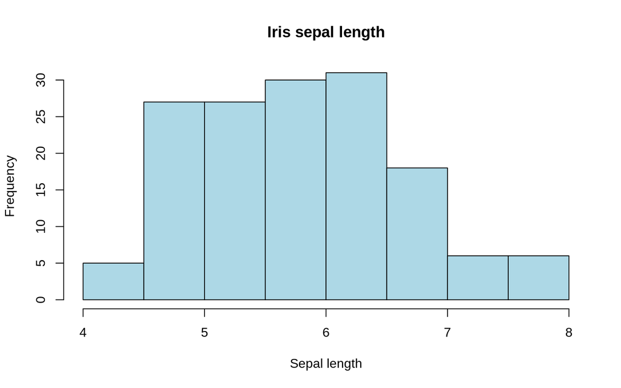

```r
data(iris) # Use the built-in Iris data set

hist(iris$Sepal.Length, col = "lightblue", main = "Iris sepal length",
        xlab = "Sepal length")
```

### Exercise 08-2 In a new code chunk below, recreate this histogram for *Iris* petal width and change the color.

**Question 04**: Run each of the three code chunks below, identify the shape of each.

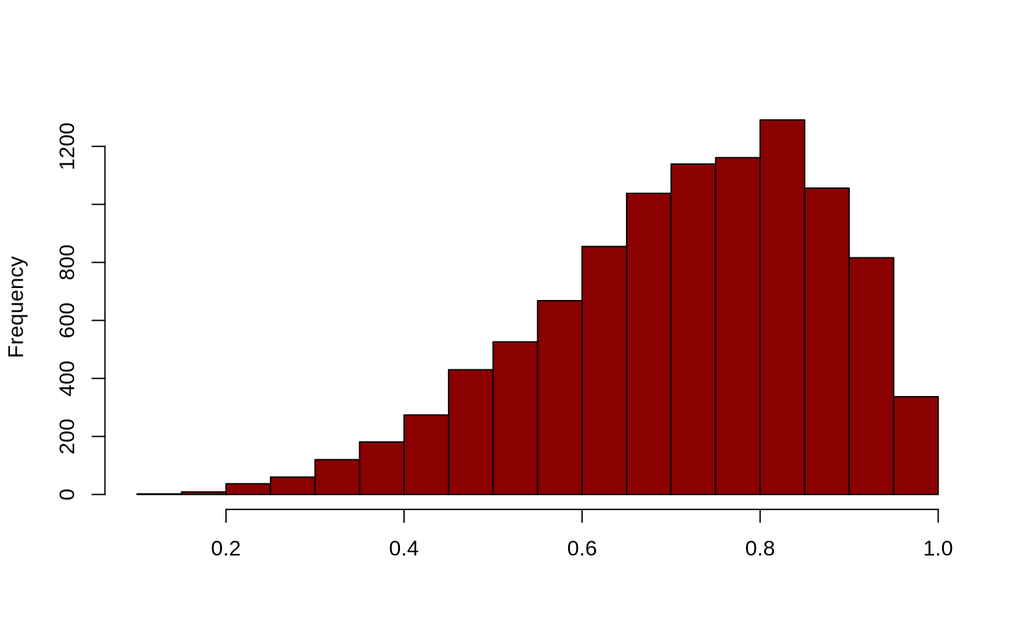

```r
hist(rbeta(10000,5,2), main = "", xlab = "", col = "darkred")
```

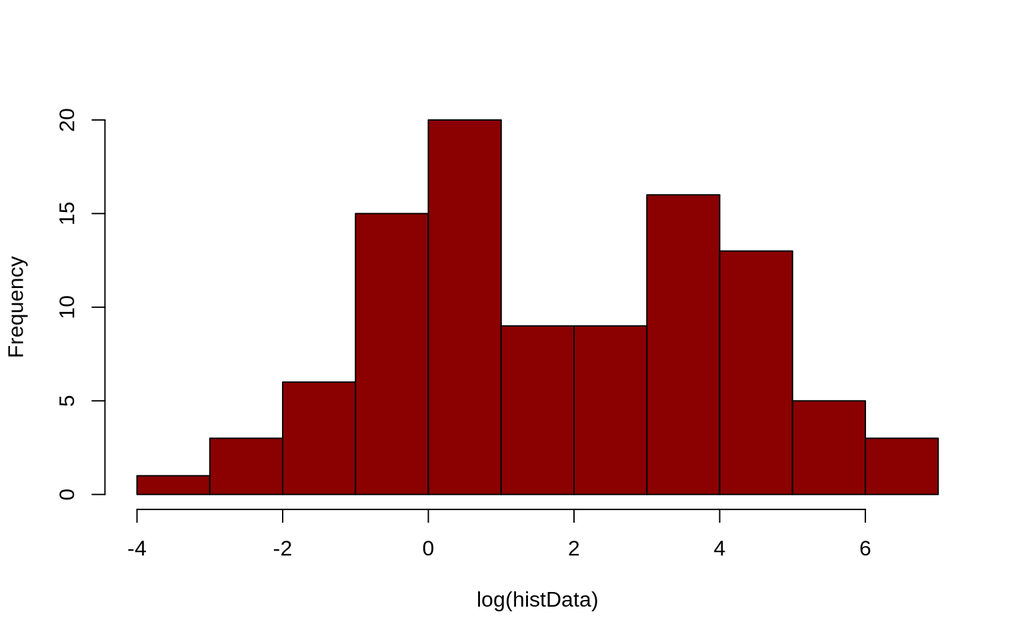

```r
mu1 <- log(1)
mu2 <- log(50)
sig1 <- log(3)
sig2 <- log(3)
cpct <- 0.4

histDistFunc <- function (n,cpct, mu1, mu2, sig1, sig2) {
  y0 <- rlnorm(n, mean = mu1, sd = sig1)
  y1 <- rlnorm(n, mean = mu2, sd = sig2)

  flag <- rbinom(n,size = 1,prob = cpct)
  y <- y0 * (1 - flag) + y1 * flag
}

histData <- histDistFunc(n = 100, cpct, mu1, mu2, sig1, sig2)
hist(log(histData), main = "", col = "darkred")
```

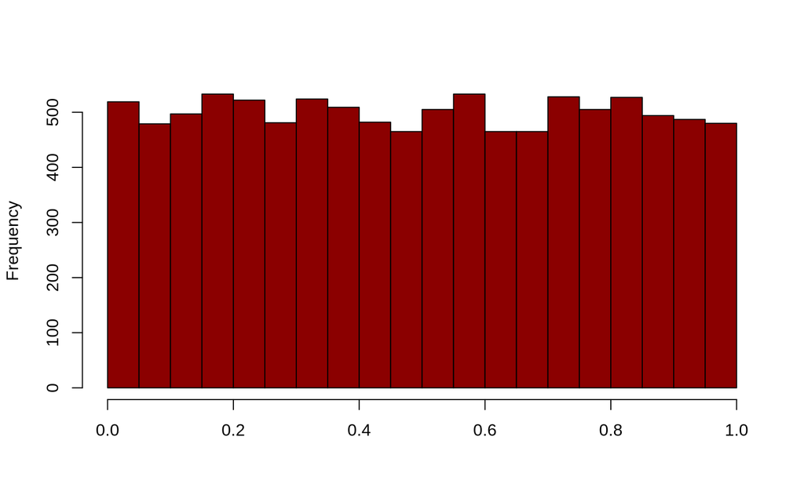

```r
hist(rbeta(10000, 1, 1), main = "", xlab = "", col = "darkred")
```

Fun code: Run this chunk to see the built-in colors in R

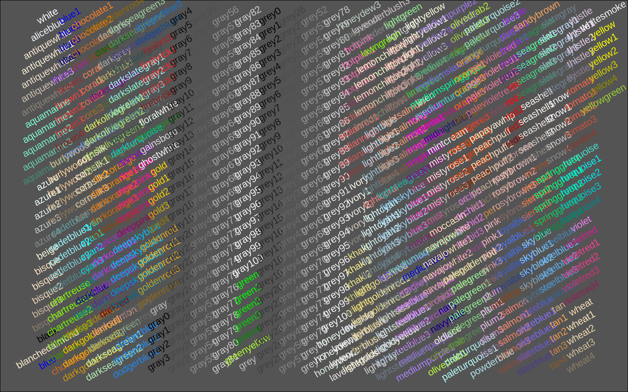

```r
showCols <- function(cl = colors(), bg = "grey",
                     cex = 0.75, rot = 30) {
    m <- ceiling(sqrt(n <- length(cl)))
    length(cl) <- m * m; cm <- matrix(cl, m)
    require("grid")
    grid.newpage(); vp <- viewport(w = .92, h = .92)
    grid.rect(gp = gpar(fill = bg))
    grid.text(cm, x = col(cm) / m, y = rev(row(cm))/m, rot = rot,
              vp = vp, gp = gpar(cex = cex, col = cm))
  }
showCols(cl = colors(), bg= "gray33", rot = 30, cex = 0.75)
```